# SITK_registration_solution

## Intensity based registration - SITK version

As the previous one, the goal of this exercise is to register two images only using their intensity values.

In this case, we will use the images of two lung CTs of the same patients taken at two different time points.

We will perform this registration using the SimpleITK library, an open-source multi-dimensional image analysis tool (https://simpleitk.org), which includes many useful functions to make our life easier while registering images.

```python
import os
import glob
import time
import numpy as np
import SimpleITK as sitk
import matplotlib.pyplot as plt
```

First of all we need to write the registration function and some utilities:

```python
def deformable_registration(fixed_slice, moving_slice, settings):

    mesh_factor = settings["mesh_size"]
    sampling_percentage = settings["sampling_percentage"]
    learning_rate = settings["learning_rate"]
    start = time.time()

    # Define the mesh size
    transform_mesh_size = [mesh_factor] * moving_slice.GetDimension()

    # Initialize the registration method
    registration_method = sitk.ImageRegistrationMethod()

    # Define the metric
    registration_method.SetMetricAsMeanSquares()
    registration_method.SetMetricSamplingStrategy(registration_method.RANDOM)
    registration_method.SetMetricSamplingPercentage(sampling_percentage)

    # Define the optimizer
    registration_method.SetOptimizerAsGradientDescent(learningRate=learning_rate, numberOfIterations=100, convergenceMinimumValue=1e-5, convergenceWindowSize=10)

    # Define the initial transform
    bspline_transform = sitk.BSplineTransformInitializer(fixed_slice, transform_mesh_size)
    registration_method.SetInitialTransform(bspline_transform, True)

    # Define the interpolator
    registration_method.SetInterpolator(sitk.sitkLinear)

    # Add auxiliary commands
    registration_method.AddCommand(sitk.sitkStartEvent, initialize_plot)
    registration_method.AddCommand(sitk.sitkEndEvent, visualize_plot)
    registration_method.AddCommand(sitk.sitkIterationEvent, lambda: fetch_metric(registration_method))

    # Execute the registration
    final_transform = registration_method.Execute(fixed_slice, moving_slice)
    end = time.time()

    # Apply the transformation on the moving slice
    registered_slice_sitk = sitk.Resample(moving_slice, fixed_slice, final_transform, sitk.sitkLinear, -1024, moving_slice.GetPixelIDValue())

    # Check the reason optimization terminated.
    print('Optimizer\'s stopping condition, {0}'.format(registration_method.GetOptimizerStopConditionDescription()))
    error = registration_method.GetMetricValue()
    elapsed_time = end-start
    print("Error:", error)
    print("Elapsed time:", elapsed_time, "seconds")

    info = {"Error": error, "Time": elapsed_time}

    return registered_slice_sitk, info
```

```python
# DEFORMABLE REGISTRATION - UTILS

# Callback invoked when the StartEvent happens, sets up new data and new figure.
def initialize_plot():
    global metric_values, fig
    fig = plt.figure(figsize=(8,4))
    metric_values = []

# Callback invoked when the EndEvent happens, display figure.
def visualize_plot():
    global metric_values, ax, fig

    plt.plot(range(len(metric_values)), metric_values, 'r')
    plt.xlabel('Iteration Number',fontsize=12)
    plt.ylabel('Metric Value',fontsize=12)
    plt.show()

    metric_values = []

# Callback invoked when the IterationEvent happens, update our data
def fetch_metric(registration_method):
    global metric_values
    metric_values.append(registration_method.GetMetricValue())
    # print("\tDeformable registration - loss:", registration_method.GetMetricValue(), flush=True)
```

Let's define a function that nicely plots our results:

```python
def plot_results(slice_1, slice_2, slice_registered):
    slice_1 = sitk.GetArrayFromImage(slice_1)
    slice_2 = sitk.GetArrayFromImage(slice_2)
    slice_registered = sitk.GetArrayFromImage(slice_registered)

    fig, ax = plt.subplots(nrows=1, ncols=5, figsize=(3*5, 3*1));
    ax[0].imshow(slice_1, cmap="gray")
    ax[1].imshow(slice_2, cmap="gray")
    ax[2].imshow(slice_1, cmap="gray", alpha=0.6);
    ax[2].imshow(slice_2, cmap="jet", alpha=0.4);
    ax[3].imshow(slice_registered, cmap="gray")
    ax[4].imshow(slice_1, cmap="gray", alpha=0.6);
    ax[4].imshow(slice_registered, cmap="jet", alpha=0.4);

    for a in ax:
        a.set_xticks([]);
        a.set_yticks([]);

    ax[0].set_title("Moving slice");
    ax[1].set_title("Fixed slice");
    ax[2].set_title("Before registration");
    ax[3].set_title("Registered slice");
    ax[4].set_title("After registration");
```

At the end of the exercise we will do a numeric and visual evaluation using the following two functions:

```python
def numeric_evaluation(info):
    x = list()
    y_error = list()
    y_time = list()

    for k in info.keys():
        x.append(k)
        y_error.append(info[k]["Error"])
        y_time.append(info[k]["Time"])

    fig, ax = plt.subplots(nrows=1, ncols=2, figsize=(16,4));
    ax[0].bar(range(len(y_error)), y_error);
    ax[0].set_xticks(range(len(y_error)));
    ax[0].set_xticklabels(x, rotation=-70);
    ax[0].set_title("Error at the final iteration", fontweight="bold");
    ax[0].set_ylabel("Metric value");

    ax[1].bar(range(len(y_time)), y_time);
    ax[1].set_xticks(range(len(y_error)));
    ax[1].set_xticklabels(x, rotation=-70);
    ax[1].set_ylabel("Seconds");
    ax[1].set_title("Computation time", fontweight="bold");

def visual_evaluation(slices):
    N = len(slices.keys())
    n_cols = 4
    n_rows = int(np.ceil(N/n_cols))
    moving_slice = sitk.GetArrayFromImage(sitk.ReadImage("./data/moving_slice.nii.gz"));

    fig, ax = plt.subplots(nrows=n_rows, ncols=n_cols, figsize=(3*n_cols, 3*n_rows));
    plt.tight_layout()
    c = 0
    r = 0
    for i in range(N):
        s = sitk.GetArrayFromImage(slices[list(slices.keys())[i]]);
        ax[r,c].imshow(s, cmap="gray");
        ax[r,c].set_title(list(slices.keys())[i]);
        ax[r,c].set_xticks([]);
        ax[r,c].set_yticks([]);
        if not c == n_cols-1:
            c += 1
        else:
            c = 0
            if not r == n_rows-1:
                r += 1
            else:
                r = 0
    ax[n_rows-1,n_cols-1].imshow(moving_slice, cmap="gray");
    ax[n_rows-1,n_cols-1].set_title("Original (moving slice)", fontweight="bold");
    ax[n_rows-1,n_cols-1].set_xticks([]);
    ax[n_rows-1,n_cols-1].set_yticks([]);
    plt.suptitle("REGISTERED SLICE", fontweight="bold", y=1.03);


    fixed_slice = sitk.GetArrayFromImage(sitk.ReadImage("./data/fixed_slice.nii.gz"));
    N = len(slices.keys())
    n_cols = 4
    n_rows = int(np.ceil(N/n_cols))

    fig, ax = plt.subplots(nrows=n_rows, ncols=n_cols, figsize=(3*n_cols, 3*n_rows));
    plt.tight_layout()
    c = 0
    r = 0
    for i in range(N):
        s = sitk.GetArrayFromImage(slices[list(slices.keys())[i]]);
        ax[r,c].imshow(s, cmap="gray", alpha=0.6);
        ax[r,c].imshow(fixed_slice, cmap="jet", alpha=0.4);
        ax[r,c].set_title(list(slices.keys())[i]);
        ax[r,c].set_xticks([]);
        ax[r,c].set_yticks([]);
        if not c == n_cols-1:
            c += 1
        else:
            c = 0
            if not r == n_rows-1:
                r += 1
            else:
                r = 0
    ax[n_rows-1,n_cols-1].imshow(moving_slice, cmap="gray", alpha=0.6);
    ax[n_rows-1,n_cols-1].imshow(fixed_slice, cmap="jet", alpha=0.4);
    ax[n_rows-1,n_cols-1].set_title("Before registration", fontweight="bold");
    ax[n_rows-1,n_cols-1].set_xticks([]);
    ax[n_rows-1,n_cols-1].set_yticks([]);
    plt.suptitle("OVERLAY", fontweight="bold", y=1.03);
```

### Let's start!

Now we can load the images that we want to work with. fixed_slice will be the reference one, we will try to register moving_slice onto it.

```python
moving_slice = sitk.ReadImage("./data/moving_slice.nii.gz")
fixed_slice = sitk.ReadImage("./data/fixed_slice.nii.gz")
```

We will need also two dictionaries to save information for the final evaluation of the results

```python
info = dict()
registered_slices = dict()
```

The following cells will register the two images changing the parameters as specified in the settings.

#### Baseline registration

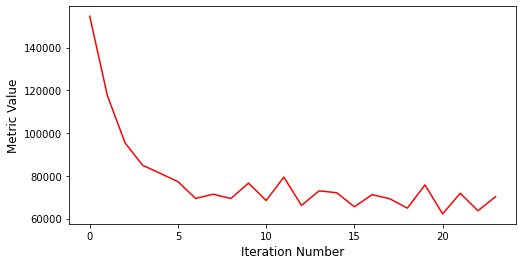

```
Optimizer's stopping condition, GradientDescentOptimizerv4Template: Convergence checker passed at iteration 24.
Error: 70179.24401077334
Elapsed time: 2.300839900970459 seconds
```

```python
settings = {"mesh_size": 8, "sampling_percentage": 0.1, "learning_rate": 0.1}
registered_slice, current_info = deformable_registration(fixed_slice, moving_slice, settings)
info["initial"] = current_info
registered_slices["initial"] = registered_slice
```

#### Registration 1 (smaller sampling_percentage)

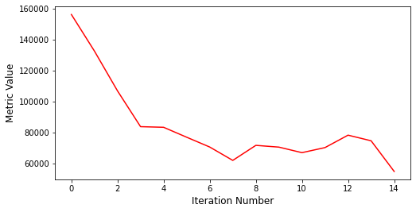

```
Optimizer's stopping condition, GradientDescentOptimizerv4Template: Convergence checker passed at iteration 15.
Error: 70759.94105211807
Elapsed time: 0.37558627128601074 seconds
```

```python
settings = {"mesh_size": 8, "sampling_percentage": 0.01, "learning_rate": 0.1}
registered_slice, current_info = deformable_registration(fixed_slice, moving_slice, settings)
info["sampling_percentage = 0.01"] = current_info
registered_slices["sampling_percentage = 0.01"] = registered_slice
```

#### Registration 2 (higher sampling_percentage)

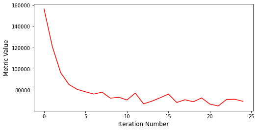

```
Optimizer's stopping condition, GradientDescentOptimizerv4Template: Convergence checker passed at iteration 25.
Error: 71897.37128876755
Elapsed time: 9.299032926559448 seconds
```

```python
settings = {"mesh_size": 8, "sampling_percentage": 0.5, "learning_rate": 0.1}
registered_slice, current_info = deformable_registration(fixed_slice, moving_slice, settings)
info["sampling_percentage = 0.5"] = current_info
registered_slices["sampling_percentage = 0.5"] = registered_slice
```

#### Registration 3 (smaller learning rate)

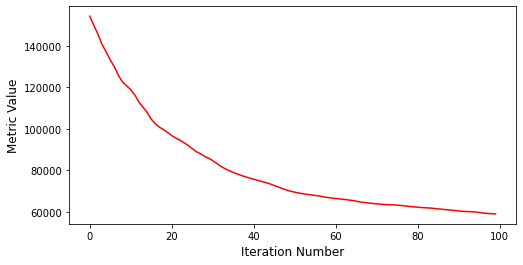

```
Optimizer's stopping condition, GradientDescentOptimizerv4Template: Maximum number of iterations (100) exceeded.
Error: 58961.98659373833
Elapsed time: 6.669452905654907 seconds
```

```python
settings = {"mesh_size": 8, "sampling_percentage": 0.1, "learning_rate": 0.01}
registered_slice, current_info = deformable_registration(fixed_slice, moving_slice, settings)
info["learning_rate = 0.01"] = current_info
registered_slices["learning_rate = 0.01"] = registered_slice
```

#### Registration 4 (higher learning rate)

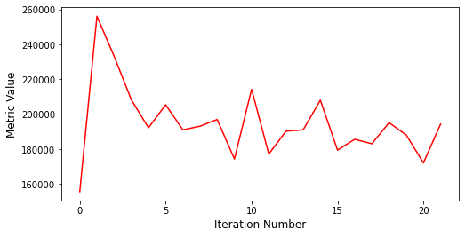

```
Optimizer's stopping condition, GradientDescentOptimizerv4Template: Convergence checker passed at iteration 22.
Error: 227451.13145949435
Elapsed time: 1.2576649188995361 seconds
```

```python
settings = {"mesh_size": 8, "sampling_percentage": 0.1, "learning_rate": 1}
registered_slice, current_info = deformable_registration(fixed_slice, moving_slice, settings)
info["learning_rate = 1"] = current_info
registered_slices["learning_rate = 1"] = registered_slice
```

#### Registration 5 (higher mesh_size)

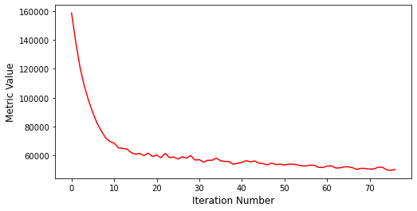

```
Optimizer's stopping condition, GradientDescentOptimizerv4Template: Convergence checker passed at iteration 77.
Error: 52722.072045879024
Elapsed time: 8.801369190216064 seconds
```

```python
settings = {"mesh_size": 16, "sampling_percentage": 0.1, "learning_rate": 0.1}
registered_slice, current_info = deformable_registration(fixed_slice, moving_slice, settings)
info["mesh_size = 16"] = current_info
registered_slices["mesh_size = 16"] = registered_slice
```

#### Registration 6 (smaller mesh_size)

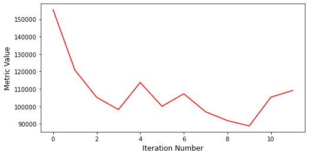

```
Optimizer's stopping condition, GradientDescentOptimizerv4Template: Convergence checker passed at iteration 12.
Error: 123733.12495513816
Elapsed time: 0.9016339778900146 seconds
```

```python
settings = {"mesh_size": 4, "sampling_percentage": 0.1, "learning_rate": 0.1}
registered_slice, current_info = deformable_registration(fixed_slice, moving_slice, settings)
info["mesh_size = 4"] = current_info
registered_slices["mesh_size = 4"] = registered_slice
```

### Visual evaluation

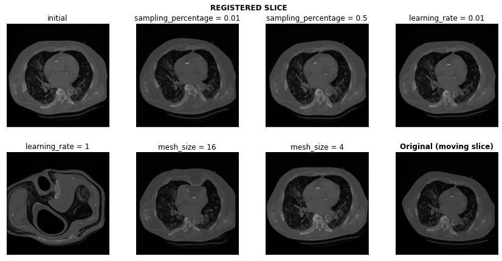

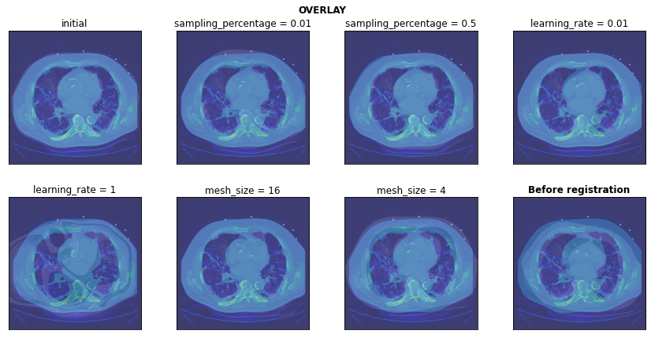

```python
visual_evaluation(registered_slices)
```

### Numeric evaluation

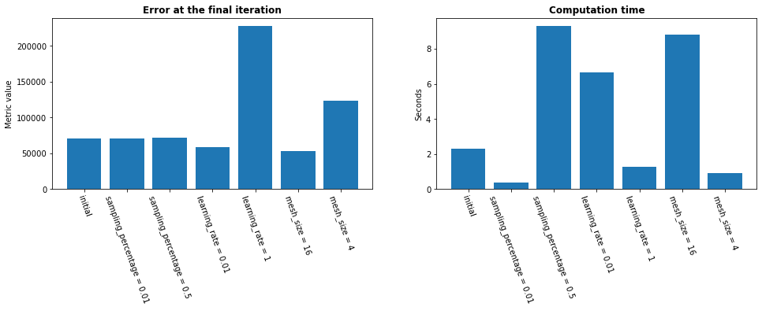

```python
numeric_evaluation(info)
```

### Find the optimal registration settings

Learning from the previous examples how do we choose the parameters to get nice results? Don't forget to take into consideration both the final error and the computation time!

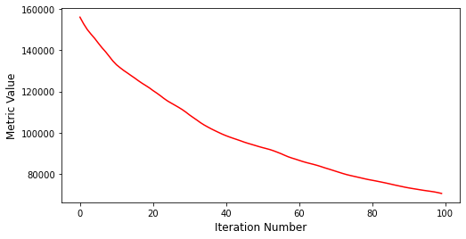

```
Optimizer's stopping condition, GradientDescentOptimizerv4Template: Maximum number of iterations (100) exceeded.
Error: 70461.20142999267
Elapsed time: 13.678072929382324 seconds
```

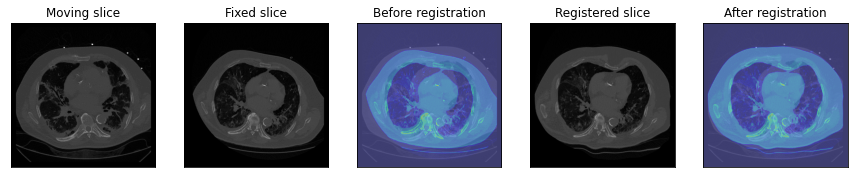

```python
settings = {"mesh_size": 16, "sampling_percentage": 0.1, "learning_rate": 0.01}
registered_slice, current_info = deformable_registration(fixed_slice, moving_slice, settings)
plot_results(fixed_slice, moving_slice, registered_slice)
```